# linearRegressionModel

Megan Kelly

2023-01-15

Scenario and Objective:

Several new airports have opened in major cities; opening the market for new routes (a route refers to a pair of airports), and Southwest has not announced whether it will cover routes to/from these cities. In order to price flights on these routes, a major airline collected information on 638 air routes in the United States. Some factors are known about these new routes: the distance traveled, demographics of the city where the new airport is located, and whether this city is a vacation destination. Other factors are yet unknown (e.g., the number of passengers who will travel this route). A major unknown factor is whether Southwest or another discount airline will travel on these new routes. Southwestʼs strategy (point-to-point routes covering only major cities, use of secondary airports, standardized fleet, low fares) has been very different from the model followed by the older and bigger airlines (hub-and-spoke model extending to even smaller cities, presence in primary airports, variety in fleet, pursuit of high-end business travelers). Find a linear regression model for predicting the average fare on a new route. Interpret the output.

```r
# 1. Load data
library(ggplot2)
library(ggpubr)
library(corrgram)
library(dplyr)
library(forecast)
airfares <- read.csv("Airfares.csv", header = TRUE)
head(airfares, 10)
```

```
##    S_CODE                 S_CITY E_CODE                 E_CITY COUPON NEW
## 1       * Dallas/Fort Worth   TX      * Amarillo            TX   1.00   3
## 2       * Atlanta             GA      * Baltimore/Wash Intl MD   1.06   3
## 3       * Boston              MA      * Baltimore/Wash Intl MD   1.06   3
## 4     ORD Chicago             IL      * Baltimore/Wash Intl MD   1.06   3
## 5     MDW Chicago             IL      * Baltimore/Wash Intl MD   1.06   3
## 6       * Cleveland           OH      * Baltimore/Wash Intl MD   1.01   3
## 7       * Dallas/Fort Worth   TX      * Baltimore/Wash Intl MD   1.28   3
## 8       * Fort Lauderdale     FL      * Baltimore/Wash Intl MD   1.15   3
## 9       * Houston             TX      * Baltimore/Wash Intl MD   1.33   3
## 10      * Kansas City         MO      * Baltimore/Wash Intl MD   1.60   2
##    VACATION  SW      HI S_INCOME E_INCOME   S_POP   E_POP       SLOT GATE
## 1        No Yes 5291.99    28637    21112 3036732  205711       Free Free
## 2        No  No 5419.16    26993    29838 3532657 7145897       Free Free
## 3        No  No 9185.28    30124    29838 5787293 7145897       Free Free
```

[output cut: 18 more lines]

```r
# Remove unnecessary variables
# Since S_Code, S_CITY, E_CODE, and E_CITY are likely to determine
# DISTANCE, and these 4 categorical variables have too many values,
# resulting in too many dummy variables,
# they are dropped from the regression model.
# Incidentally, they are also not included in the new record.

airfares <- airfares[, -c(1:4)]
airfares <- airfares[, -c(3,4,10,11)]
names(airfares)
```

```
##  [1] "COUPON"   "NEW"      "HI"       "S_INCOME" "E_INCOME" "S_POP"
##  [7] "E_POP"    "DISTANCE" "PAX"      "FARE"
```

```r
# Correlations and training-validation split


set.seed(666)

train_index <- sample(1:nrow(airfares), 0.6 * nrow(airfares))
valid_index <- setdiff(1:nrow(airfares), train_index)
train_df <- airfares[train_index, ]
valid_df <- airfares[valid_index, ]



#check
nrow(train_df)
```

```
## [1] 382
```

```r
nrow(valid_df)
```

```
## [1] 256
```

```r
head(train_df)
```

```
##     COUPON NEW      HI S_INCOME E_INCOME   S_POP   E_POP DISTANCE   PAX   FARE
## 574   1.89   3 2225.74    22089    31981  668159 4549784     1643  3740 215.57
## 608   1.00   3 2487.89    32991    31981 8621121 4549784      217 63690 114.35
## 123   1.34   3 2883.65    24575    25475 1197234 1489247     1588  7406 114.13
## 540   1.03   3 4901.10    28739    25824 2761118 2549844      457  4826 202.77
## 50    1.01   0 3910.81    25059    29260 1595139 7830332      254  7069 180.56
## 131   1.28   3 3076.53    23654    25475 2195215 1489247      844  5160  99.43
```

```r
head(valid_df)
```

```
##    COUPON NEW      HI S_INCOME E_INCOME   S_POP   E_POP DISTANCE  PAX   FARE
## 2    1.06   3 5419.16    26993    29838 3532657 7145897      576 8820 174.47
## 12   1.50   1 3932.29    24706    29838 9056076 7145897     2329 7349 228.99
## 13   1.12   3 4471.62    25995    29838 1115048 7145897      587 5654  79.17
## 14   1.29   3 4356.12    22038    29838 1308499 7145897      992 3525 132.05
## 15   1.00   3 2626.90    32991    29838 8621121 7145897      181 7171 117.23
## 16   1.00   3 2626.90    32991    29838 8621121 7145897      181 7171 117.23
```

[figure not shown]

```r
# correlation
#install.packages("corrgram")
library(corrgram)

corrgram(train_df)
```

```r
cor(train_df)
```

```
##               COUPON          NEW          HI    S_INCOME    E_INCOME
## COUPON    1.00000000  0.018547315 -0.38663306 -0.18604105  0.06294362
## NEW       0.01854732  1.000000000  0.02882838 -0.04964667  0.13018727
## HI       -0.38663306  0.028828379  1.00000000  0.03289966  0.08336164
## S_INCOME -0.18604105 -0.049646670  0.03289966  1.00000000 -0.18508018
## E_INCOME  0.06294362  0.130187275  0.08336164 -0.18508018  1.00000000
## S_POP    -0.18487385 -0.038284370 -0.07834743  0.51637130 -0.15212886
## E_POP     0.15729603  0.088964587 -0.10961935 -0.31456037  0.42065795
## DISTANCE  0.73686173  0.096615554 -0.35625281 -0.04997598  0.19493466
## PAX      -0.34477588  0.005575263 -0.16039055  0.15201566  0.27909442
## FARE      0.49599378  0.118340391 -0.01094012  0.16549632  0.30689238
##                S_POP       E_POP    DISTANCE          PAX        FARE
## COUPON   -0.18487385  0.15729603  0.73686173 -0.344775883  0.49599378
## NEW      -0.03828437  0.08896459  0.09661555  0.005575263  0.11834039
## HI       -0.07834743 -0.10961935 -0.35625281 -0.160390551 -0.01094012
## S_INCOME  0.51637130 -0.31456037 -0.04997598  0.152015664  0.16549632
## E_INCOME -0.15212886  0.42065795  0.19493466  0.279094423  0.30689238
## S_POP     1.00000000 -0.27414791 -0.04810911  0.321823933  0.14974024
## E_POP    -0.27414791  1.00000000  0.16017486  0.318280760  0.26249249
## DISTANCE -0.04810911  0.16017486  1.00000000 -0.092993058  0.67632661
## PAX       0.32182393  0.31828076 -0.09299306  1.000000000 -0.06843540
## FARE      0.14974024  0.26249249  0.67632661 -0.068435401  1.00000000
```

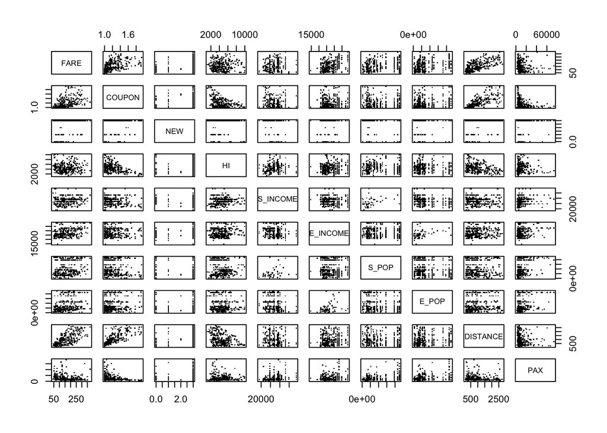

```r
pairs(FARE ~ ., data = train_df, pch = ".")
```

[figure not shown]

```r
corrgram(train_df)
```

```r
#install.packages("ggplot2")
library(ggplot2)
library(ggpubr)


str(airfares$DISTANCE)
```

```
##  int [1:638] 312 576 364 612 612 309 1220 921 1249 964 ...
```

```r
str(airfares$FARE)
```

```
##  num [1:638] 64.1 174.5 207.8 85.5 85.5 ...
```

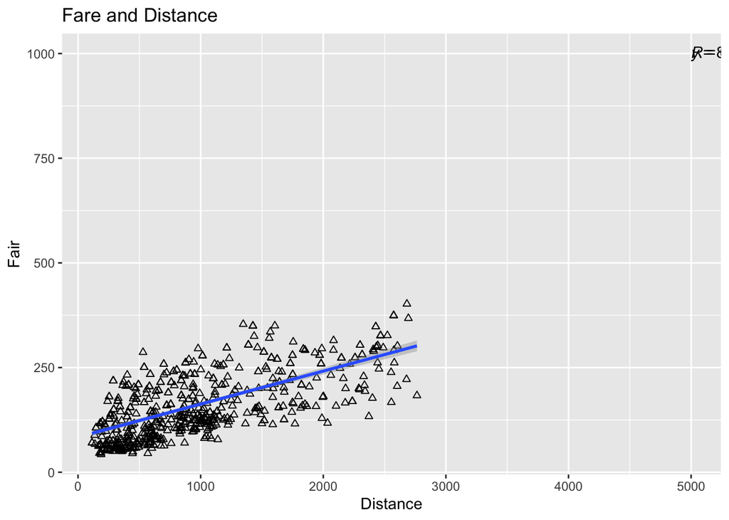

```r
ggplot(airfares) + aes(x = DISTANCE, y = FARE) +
  geom_point(shape = 2, colour = "black") +
  xlab("Distance") + ylab("Fair") +
  ggtitle("Fare and Distance") +
  geom_smooth(method = lm) +
  stat_regline_equation(label.x = 5000, label.y = 1000) +
  stat_cor(method = "pearson", label.x = 5000, label.y = 1000)
```

```r
# 3 Regression model
airfares2 <- airfares[, c("DISTANCE", "PAX", "E_INCOME", "S_INCOME",
                          "S_POP", "E_POP", "NEW", "FARE")]
head(airfares2)
```

```
##   DISTANCE   PAX E_INCOME S_INCOME   S_POP   E_POP NEW   FARE
## 1      312  7864    21112    28637 3036732  205711   3  64.11
## 2      576  8820    29838    26993 3532657 7145897   3 174.47
## 3      364  6452    29838    30124 5787293 7145897   3 207.76
## 4      612 25144    29838    29260 7830332 7145897   3  85.47
## 5      612 25144    29838    29260 7830332 7145897   3  85.47
## 6      309 13386    29838    26046 2230955 7145897   3  56.76
```

```r
library(dplyr)
airfares2 <- airfares2 %>% mutate_if(is.character, as.numeric)
str(airfares2)
```

```
## 'data.frame':    638 obs. of  8 variables:
##  $ DISTANCE: int  312 576 364 612 612 309 1220 921 1249 964 ...
##  $ PAX     : int  7864 8820 6452 25144 25144 13386 4625 5512 7811 4657 ...
##  $ E_INCOME: int  21112 29838 29838 29838 29838 29838 29838 29838 29838 29838 ...
##  $ S_INCOME: int  28637 26993 30124 29260 29260 26046 28637 26752 27211 25450 ...
##  $ S_POP   : int  3036732 3532657 5787293 7830332 7830332 2230955 3036732 1440377 3770125 1694803 ...
##  $ E_POP   : int  205711 7145897 7145897 7145897 7145897 7145897 7145897 7145897 7145897 7145897 ...
##  $ NEW     : int  3 3 3 3 3 3 3 3 3 2 ...
##  $ FARE    : num  64.1 174.5 207.8 85.5 85.5 ...
```

```r
names(airfares2)
```

```
## [1] "DISTANCE" "PAX"      "E_INCOME" "S_INCOME" "S_POP"    "E_POP"    "NEW"
## [8] "FARE"
```

```r
fares_model <- lm(FARE ~ PAX + E_INCOME + S_INCOME + S_POP +
                    E_POP + NEW,
                  data = airfares2)
summary(fares_model)
```

```
##
## Call:
## lm(formula = FARE ~ PAX + E_INCOME + S_INCOME + S_POP + E_POP +
##     NEW, data = airfares2)
##
## Residuals:
##      Min       1Q   Median       3Q      Max
## -177.552  -39.066   -5.465   38.214  183.271
##
## Coefficients:
##               Estimate Std. Error t value Pr(>|t|)
## (Intercept) -1.965e+02  2.699e+01  -7.279 1.01e-12 ***
## PAX         -2.476e-03  2.135e-04 -11.596  < 2e-16 ***
## E_INCOME     5.235e-03  5.976e-04   8.760  < 2e-16 ***
## S_INCOME     5.896e-03  7.937e-04   7.428 3.59e-13 ***
## S_POP        7.322e-06  1.010e-06   7.248 1.24e-12 ***
## E_POP        1.195e-05  1.097e-06  10.897  < 2e-16 ***
## NEW          3.246e+00  3.189e+00   1.018    0.309
## ---
## Signif. codes:  0 '***' 0.001 '**' 0.01 '*' 0.05 '.' 0.1 ' ' 1
##
## Residual standard error: 60.7 on 631 degrees of freedom
## Multiple R-squared:  0.3685, Adjusted R-squared:  0.3625
## F-statistic: 61.38 on 6 and 631 DF,  p-value: < 2.2e-16
```

```r
coef(fares_model)
```

```
##   (Intercept)           PAX      E_INCOME      S_INCOME         S_POP
## -1.964571e+02 -2.476239e-03  5.235181e-03  5.896049e-03  7.322327e-06
##         E_POP           NEW
##  1.195207e-05  3.245808e+00
```

```r
confint(fares_model, level = 0.95)
```

```
##                     2.5 %        97.5 %
## (Intercept) -2.494599e+02 -1.434543e+02
## PAX         -2.895572e-03 -2.056905e-03
## E_INCOME     4.061622e-03  6.408740e-03
## S_INCOME     4.337390e-03  7.454709e-03
## S_POP        5.338407e-06  9.306248e-06
## E_POP        9.798222e-06  1.410591e-05
## NEW         -3.015860e+00  9.507475e+00
```

```r
fares_model_std <- lm.beta::lm.beta(fares_model)


coef(fares_model_std)
```

```
## (Intercept)         PAX    E_INCOME    S_INCOME       S_POP       E_POP
##          NA -0.43002924  0.31755259  0.27891001  0.29001201  0.43008518
##         NEW
##  0.03246763
```

```r
confint(fares_model_std)
```

```
##                  2.5 %     97.5 %
## (Intercept)         NA         NA
## PAX         -0.4304486 -0.4296099
## E_INCOME     0.3163790  0.3187261
## S_INCOME     0.2773514  0.2804687
## S_POP        0.2900100  0.2900140
## E_POP        0.4300830  0.4300873
## NEW         -6.2291999  6.2941352
```

```r
#training set
#install.packages("forecast")
library(forecast)
fares_model_pred_train <- predict(fares_model,
                                  train_df)



# predict validation set

fares_model_pred <- predict(fares_model,
                            valid_df)

# model evaluation

accuracy(fares_model_pred_train, train_df$FARE)
```

```
##                ME     RMSE      MAE       MPE     MAPE
## Test set 1.340004 60.77022 47.71996 -16.59001 37.47233
```

```r
accuracy(fares_model_pred, valid_df$FARE)
```

```
##                 ME     RMSE      MAE       MPE     MAPE
## Test set -1.999537 59.75155 48.13665 -15.72559 36.42055
```

```r
max(train_df$FARE) - min(train_df$FARE)
```

```
## [1] 331.93
```

```r
sd(train_df$FARE)
```

```
## [1] 75.26405
```

```r
max(valid_df$FARE) - min(valid_df$FARE)
```

```
## [1] 356.91
```

```r
sd(valid_df$FARE)
```

```
## [1] 77.23585
```

```r
# 4 create new record ----------------------------------------------------------------------

new_record <- data.frame(COUPON = 1.202, NEW = 3,
                         VACATION = "Yes", SW = "Yes",
                         HI = 4442.141, S_INCOME = 28760,
                         E_INCOME = 27664, S_POP = 4557004,
                         E_POP = 3195503, SLOT = "Free",
                         GATE = "Free", PAX = 12782,
                         DISTANCE = 1976)

# predict fare for new record

fares_model_pred_new <- predict(fares_model,
                                newdata = new_record, interval = "confidence")
fares_model_pred_new
```

```
##        fit      lwr      upr
## 1 167.5862 162.4077 172.7647
```

```r
#pred = 167.59
```